# Examen_Final_DIP

150074

6/12/2017

# Examen Final Minería de Datos Agosto Diciembre 2017

### 14 David Alcalde

### 150074 Iovannah Rudoy

### 150553 Paloma Lever

## Agenda

- Tema
- Introducción
- Datos
- K-means
- Dendograma
- Preguntas
- Conclusiones

### Tema

A nuestro equipo le fue asignado el siguiente tema (tema 2) en la clase del 4 de Diciembre del 2017

#### Agrupación

Cuentas con un set de datos que contiene información relacionada a la contaminación de Beijing -**PM2.5**- del 1 de enero de 2010 al 31 de diciembre del 2014. El set cuenta con las siguientes variables

- **No:** row number
- **year:** year of data in this row
- **month:** month of data in this row
- **day:** day of data in this row
- **hour:** hour of data in this row
- **pm2.5:** PM2.5 concentration ($ug/m^3$)
- **DEWP:** Dew Point, it’s a more accurate way of measuring the humidity and comfort of air,
- **TEMP:** Temperature
- **PRES:** Pressure (hPa)
- **cbwd:** Combined wind direction
- **lws:** Cumulated wind speed (m/s)
- **ls:** Cumulated hours or snow
- **lr:** Cumulated hours of rain

Lo que tienes que hacer:

- Elimina del set las variables: `No`, `year`, `month`, `day`
- Genera un k-means ocupando el resto de las variables
- Genera un dendograma con el resto de las variables

### Introducción

La contaminaci?n en el medio ambiente es una consecuencia inmediata de la industrializaci?n y la tecnificaci?n de la vida, a lo largo de los a?os ha dejado una capa cada vez m?s densa en las ciudades m?s pobladas del mundo y se ha convertido en una amenaza para la salud p?blica y no se han hecho los suficientes cambios en la industria para poder combatir exitosamente este fen?meno. Una investigaci?n del Colegio del Medio Ambiente de la Universidad de Nanjing relacion? la contaminaci?n con casi un tercio de todas las muertes que se producen en China, ubicando a la poluci?n en el mismo nivel que fumar tabaco como amenaza para la salud p?blica

Teniendo un set de datos que contiene informaci?n relevante respecto al nivel de contaminaci?n de la ciudad de Behin en 5 a?os, el objetivo es lograr su agrupaci?n mediante el uso de dos m?todos no supervisados de agrpaci?n que son k-means clustering y dendogramas para as? poder centrar nuestro an?lisis de estos en grupos que compartan ciertas caracter?sticas entre s? y conocer qu? es lo que los diiferencia

### Datos

```r
set.seed(14)
#Iovannah
data <- read_csv('~/Desktop/Mineria_de_datos/pollution.csv')
#Paloma
#data <- read_csv("../data/pollution.csv")
summary(data)
```

```
##        No             year          month             day
##  Min.   :    1   Min.   :2010   Min.   : 1.000   Min.   : 1.00
##  1st Qu.:10957   1st Qu.:2011   1st Qu.: 4.000   1st Qu.: 8.00
##  Median :21912   Median :2012   Median : 7.000   Median :16.00
##  Mean   :21912   Mean   :2012   Mean   : 6.524   Mean   :15.73
##  3rd Qu.:32868   3rd Qu.:2013   3rd Qu.:10.000   3rd Qu.:23.00
##  Max.   :43824   Max.   :2014   Max.   :12.000   Max.   :31.00
##
##       hour           pm2.5             DEWP              TEMP
##  Min.   : 0.00   Min.   :  0.00   Min.   :-40.000   Min.   :-19.00
##  1st Qu.: 5.75   1st Qu.: 29.00   1st Qu.:-10.000   1st Qu.:  2.00
##  Median :11.50   Median : 72.00   Median :  2.000   Median : 14.00
##  Mean   :11.50   Mean   : 98.61   Mean   :  1.817   Mean   : 12.45
##  3rd Qu.:17.25   3rd Qu.:137.00   3rd Qu.: 15.000   3rd Qu.: 23.00
##  Max.   :23.00   Max.   :994.00   Max.   : 28.000   Max.   : 42.00
##                  NA's   :2067                       NA's   :2
##       PRES          cbwd                Iws               Is
##  Min.   : 991   Length:43824       Min.   :  0.45   Min.   : 0.00000
##  1st Qu.:1008   Class :character   1st Qu.:  1.79   1st Qu.: 0.00000
##  Median :1016   Mode  :character   Median :  5.37   Median : 0.00000
##  Mean   :1016                      Mean   : 23.89   Mean   : 0.05273
##  3rd Qu.:1025                      3rd Qu.: 21.91   3rd Qu.: 0.00000
##  Max.   :1046                      Max.   :585.60   Max.   :27.00000
##  NA's   :4
##        Ir
##  Min.   : 0.0000
##  1st Qu.: 0.0000
##  Median : 0.0000
##  Mean   : 0.1949
##  3rd Qu.: 0.0000
##  Max.   :36.0000
##
```

```r
#Eliminamos 2000 valores vacíos que tenía la base de datos para la variable pw2.5
data <- na.omit(data)
#Sin numero ni dia
data<- data[,-c(1,4)]
data$year <- factor(data$year)
data$month <- factor(data$month)
variables <- names(data)
rows <- dim(data)[1]

clases <- sapply(data, function(x) class(x))
```

El numero total de observaciones en el dataset es 41751

**Estadística general, Data Profiling*

|  | uniques | nan | minimo | maximo | promedio | desvest | mediana | moda | primer_cuartil | tercer_cuartil |
| --- | --- | --- | --- | --- | --- | --- | --- | --- | --- | --- |
| hour | 24 | 0 | 0.00 | 23.00 | 11.5014251 | 6.9248968 | 12.00 | 18 | 5.00 | 18.00 |
| pm2.5 | 581 | 0 | 0.00 | 994.00 | 98.6167996 | 92.0525716 | 72.00 | 16 | 29.00 | 137.00 |
| DEWP | 69 | 0 | -40.00 | 28.00 | 1.7513832 | 14.4342402 | 2.00 | 18 | -10.00 | 15.00 |
| TEMP | 62 | 0 | -19.00 | 42.00 | 12.4026730 | 12.1755584 | 14.00 | 24 | 2.00 | 23.00 |
| PRES | 56 | 0 | 991.00 | 1,046.00 | 1,016.4417858 | 10.3008171 | 1,016.00 | 1014 | 1,008.00 | 1,025.00 |
| Iws | 2,721 | 0 | 0.45 | 565.49 | 23.8622105 | 49.6112423 | 5.37 | 0.89 | 1.79 | 21.91 |
| Is | 28 | 0 | 0.00 | 27.00 | 0.0553520 | 0.7789304 | 0.00 | 0 | 0.00 | 0.00 |
| Ir | 37 | 0 | 0.00 | 36.00 | 0.1948935 | 1.4182654 | 0.00 | 0 | 0.00 | 0.00 |

Podemos decir del PM2.5 que es una variable numérica que va del 0 al 994, con una desviación estándar de 92. Además, la media de esta variable es 98, lo que significa que los números mayores a 200 deberían ser alarmantes que estan contenidos en menos del 25% de los datos. La temperatura en Beijing var?a mucho a lo largo del a?o y en las distintas regions, va de -19C a 42C. DEWP es el grado de humedad, normalmente va de 10 a 26 grados y cualquier valor arriba o abajo puede causar un gran disomfort para el ser humano ya que menor a 10?C incluso menor a 0?C puede ser demasaido seco o mayor a 30?C puede ser asfixiante. En Beijing vemos que va de -40? a 28? lo cual est? relacionado con las teperaturas extremas a la sque llega a alcanzar.

|  | uniques | nan | moda |
| --- | --- | --- | --- |
| year | 5 | 0 | 2013 |
| month | 12 | 0 | 7 |
| cbwd | 4 | 0 | SE |

Tenemos 5 años, con una moda del 2013, 12 meses con una moda en Julio y 4 valores para cbwd con una moda de SE (South East).

Preparamos los datos

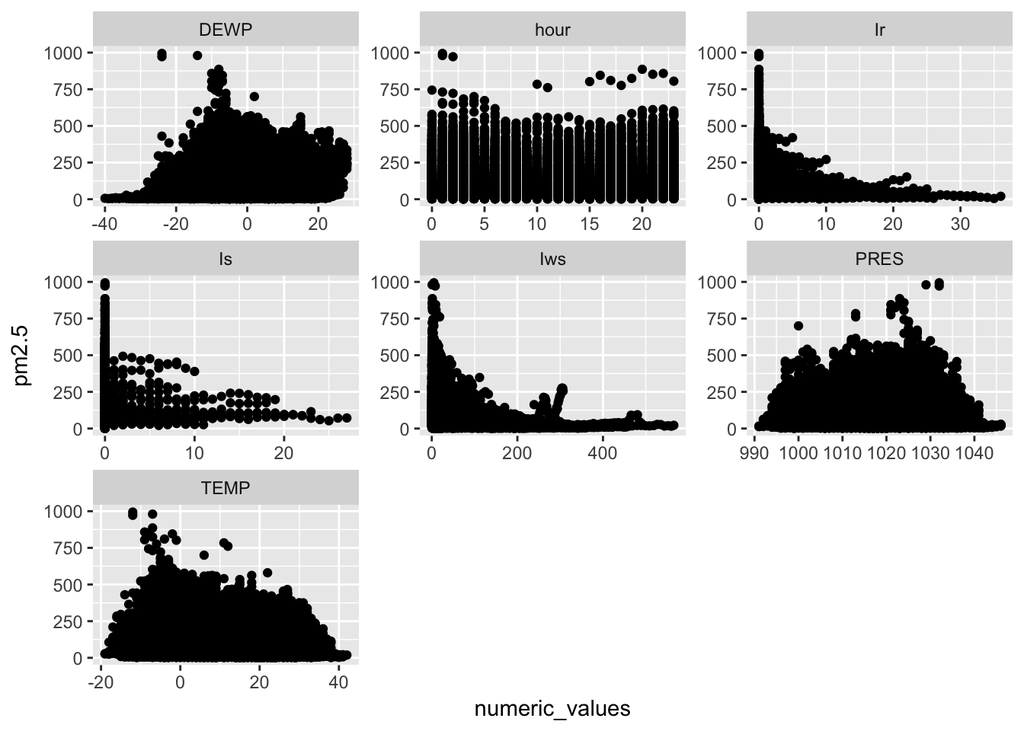

Al ver los datos podemos observar que la hora no es un dato constante.

```
##       hour             pm2.5              DEWP               TEMP
##  Min.   :-1.6609   Min.   :-1.0713   Min.   :-2.89252   Min.   :-2.5792
##  1st Qu.:-0.9388   1st Qu.:-0.7563   1st Qu.:-0.81413   1st Qu.:-0.8544
##  Median : 0.0720   Median :-0.2891   Median : 0.01722   Median : 0.1312
##  Mean   : 0.0000   Mean   : 0.0000   Mean   : 0.00000   Mean   : 0.0000
##  3rd Qu.: 0.9384   3rd Qu.: 0.4170   3rd Qu.: 0.91786   3rd Qu.: 0.8704
##  Max.   : 1.6605   Max.   : 9.7269   Max.   : 1.81850   Max.   : 2.4309
##       PRES               Iws                 Is
##  Min.   :-2.46988   Min.   :-0.47191   Min.   :-0.07106
##  1st Qu.:-0.81953   1st Qu.:-0.44490   1st Qu.:-0.07106
##  Median :-0.04289   Median :-0.37274   Median :-0.07106
##  Mean   : 0.00000   Mean   : 0.00000   Mean   : 0.00000
##  3rd Qu.: 0.83083   3rd Qu.:-0.03935   3rd Qu.:-0.07106
##  Max.   : 2.86950   Max.   :10.91744   Max.   :34.59186
##        Ir
##  Min.   :-0.1374
##  1st Qu.:-0.1374
##  Median :-0.1374
##  Mean   : 0.0000
##  3rd Qu.:-0.1374
##  Max.   :25.2457
```

### K-means

Las variables que màs nos interesan para aplicar el algoritmo son las numericas por lo que quitamos CBWD, año y mes.

¿Cuántos grupos generaste? Para decidir el numero de grupos, hacemos el metodo del codo generando hasta 10 clusters.

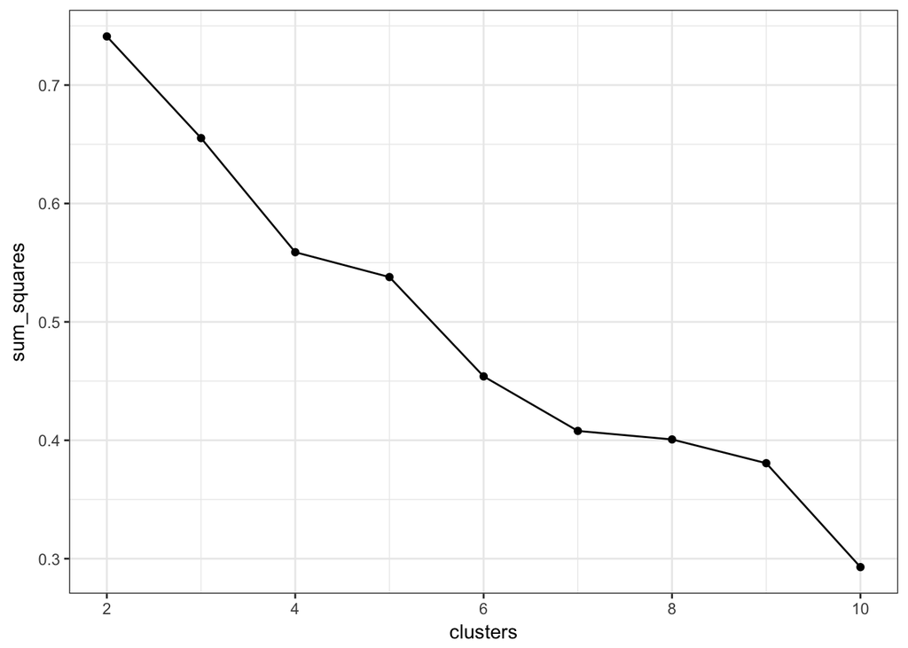

```r
retail_scaled <- data_scale

k_2  <- kmeans(retail_scaled, centers=2, iter.max=10)
k_3  <- kmeans(retail_scaled, centers=3, iter.max=10)
k_4  <- kmeans(retail_scaled, centers=4, iter.max=10)
k_5  <- kmeans(retail_scaled, centers=5, iter.max=10)
k_6  <- kmeans(retail_scaled, centers=6, iter.max=10)
k_7  <- kmeans(retail_scaled, centers=7, iter.max=10)
k_8  <- kmeans(retail_scaled, centers=8, iter.max=10)
k_9  <- kmeans(retail_scaled, centers=9, iter.max=10)
k_10 <- kmeans(retail_scaled, centers=10, iter.max=10)

tot_sumsquares <- k_2$totss

elbow_data <- data.frame(clusters = c(2,3,4,5,6,7,8,9,10),
                         sum_squares =c(k_2$tot.withinss/tot_sumsquares,
                                        k_3$tot.withinss/tot_sumsquares,
                                        k_4$tot.withinss/tot_sumsquares,
                                        k_5$tot.withinss/tot_sumsquares,
                                        k_6$tot.withinss/tot_sumsquares,
                                        k_7$tot.withinss/tot_sumsquares,
                                        k_8$tot.withinss/tot_sumsquares,
                                        k_9$tot.withinss/tot_sumsquares,
                                        k_10$tot.withinss/tot_sumsquares
                                        ))

ggplot(elbow_data, aes(x=clusters, y=sum_squares)) +
  geom_point() +
  geom_line() +
  theme_bw()
```

Con el metodo del codo vemos que el punto optimo es tener 7 clusters ya que si elijieramos 6 veriamos que aun sigue bajando la suma de cuadrados y con 8 y 9 la diferencia que hay es menor a 0.1.

```r
table(k_7$cluster)
```

```
##
##     1     2     3     4     5     6     7
##  4333   161  9413 10570  8147  7287  1840
```

Podemos observar las coordenadas de cada centro:

```r
k_7$centers
```

```
##          hour       pm2.5       DEWP       TEMP       PRES         Iws
## 1  0.02933871  2.14507163 -0.1705170 -0.6392133  0.3326148 -0.37111222
## 2 -0.11904964  0.25881074 -0.4767704 -1.3247344  1.0129284  0.29569211
## 3 -0.90525077 -0.04714526  0.8678123  0.5744654 -0.7033561 -0.25629090
## 4  0.77364628 -0.15860561  0.8249849  1.0873697 -0.9033707 -0.14550644
## 5  0.81303119 -0.40837006 -0.8983957 -0.5347947  0.7119427 -0.03893226
## 6 -0.88324144 -0.32077633 -0.8894683 -1.1122928  0.9767746 -0.16825150
## 7  0.02616408 -0.84322628 -1.2350067 -0.7911394  0.8951440  3.83376193
##            Is          Ir
## 1 -0.03639592 -0.11544898
## 2 14.14655645 -0.13741683
## 3 -0.07106151  0.36946954
## 4 -0.07106151 -0.07264492
## 5 -0.05766713 -0.11950190
## 6 -0.01362736 -0.13199830
## 7 -0.07106151 -0.13703363
```

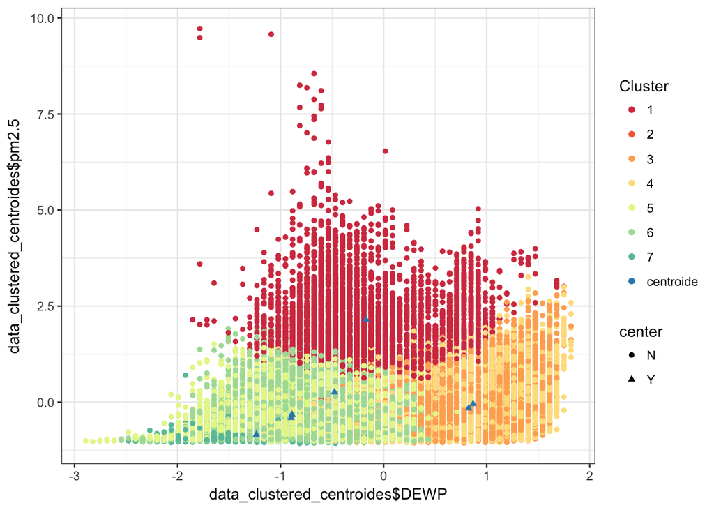

```r
centroides <- as.data.frame(k_7$centers)
centroides$center <- "Y"
centroides$cluster <- "centroide"

data_clustered <- data_scale
data_clustered$cluster <- k_7$cluster
data_clustered$center <- "N"
data_clustered_centroides <- rbind(data_clustered,centroides)



ggplot(data_clustered_centroides, aes(x=data_clustered_centroides$DEWP, y=data_clustered_centroides$pm2.5,
                                    color= as.factor(cluster), shape=center)) + geom_point() + scale_color_brewer(palette="Spectral",name="Cluster")+ theme_bw()
```

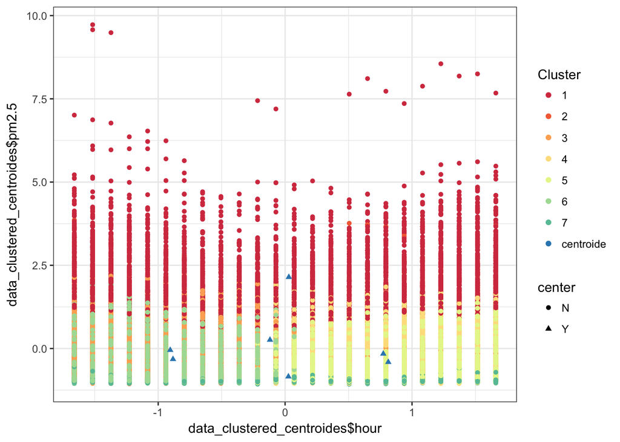

```r
ggplot(data_clustered_centroides, aes(x=data_clustered_centroides$hour, y=data_clustered_centroides$pm2.5,
                                    color= as.factor(cluster), shape=center)) + geom_point() + scale_color_brewer(palette="Spectral",name="Cluster")+ theme_bw()
```

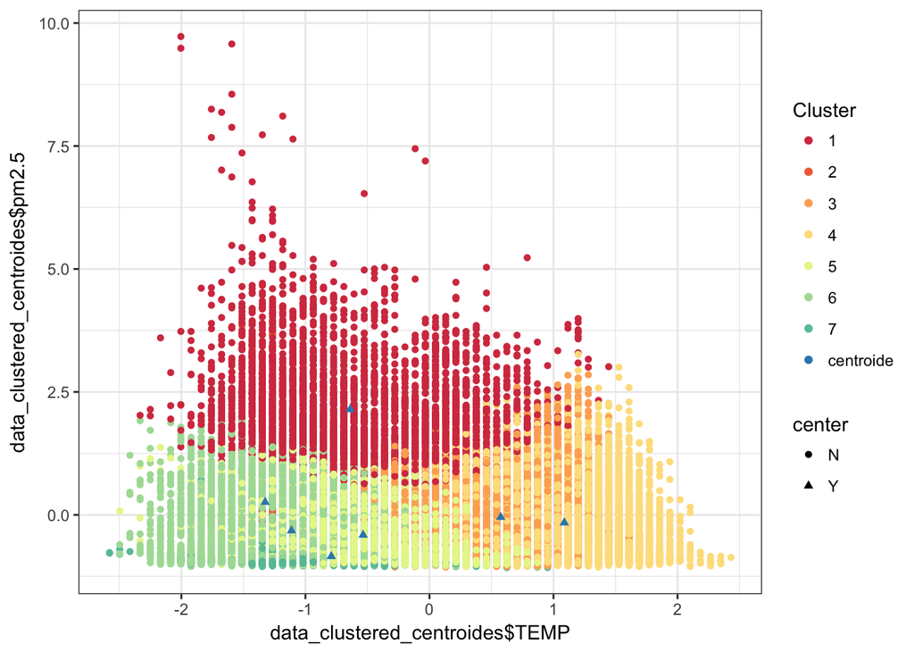

```r
ggplot(data_clustered_centroides, aes(x=data_clustered_centroides$TEMP, y=data_clustered_centroides$pm2.5,
                                    color= as.factor(cluster), shape=center)) + geom_point() + scale_color_brewer(palette="Spectral",name="Cluster")+ theme_bw()
```

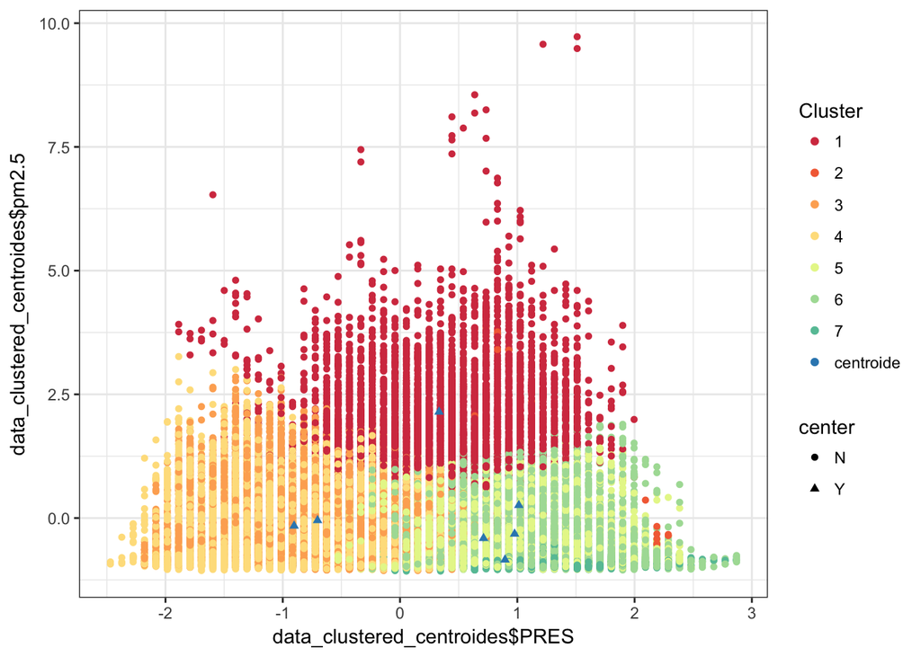

```r
ggplot(data_clustered_centroides, aes(x=data_clustered_centroides$PRES, y=data_clustered_centroides$pm2.5,
                                    color= as.factor(cluster), shape=center)) + geom_point() + scale_color_brewer(palette="Spectral",name="Cluster")+ theme_bw()
```

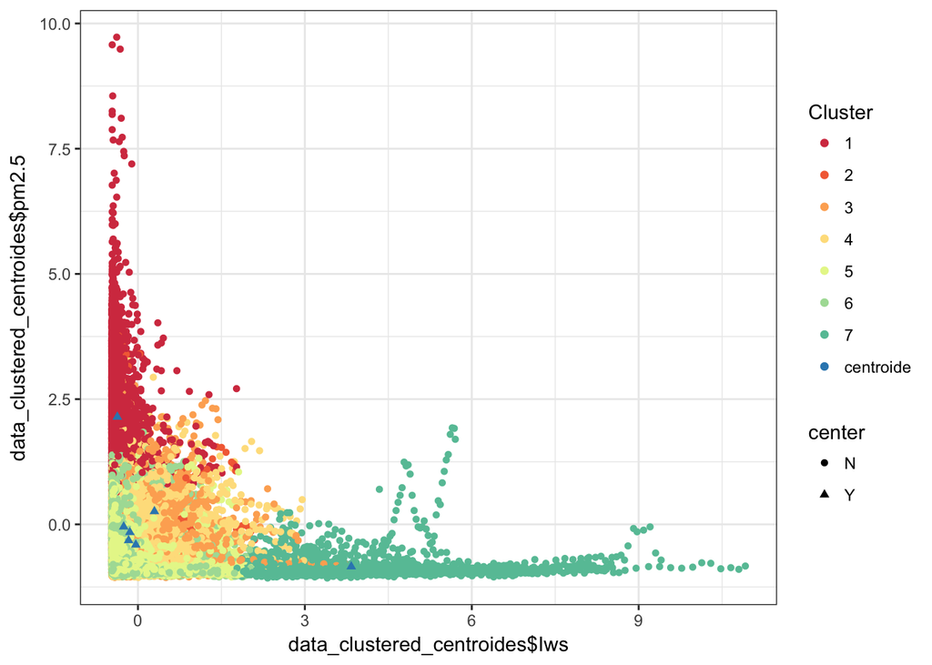

```r
ggplot(data_clustered_centroides, aes(x=data_clustered_centroides$Iws, y=data_clustered_centroides$pm2.5,
                                    color= as.factor(cluster), shape=center)) + geom_point() + scale_color_brewer(palette="Spectral",name="Cluster")+ theme_bw()
```

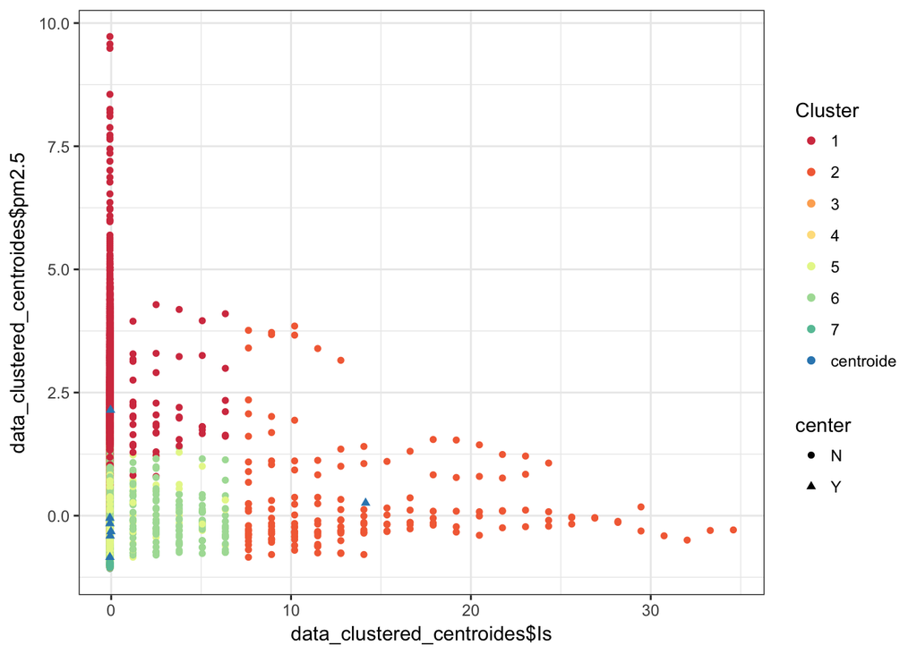

```r
ggplot(data_clustered_centroides, aes(x=data_clustered_centroides$Is, y=data_clustered_centroides$pm2.5,
                                    color= as.factor(cluster), shape=center)) + geom_point() + scale_color_brewer(palette="Spectral",name="Cluster")+ theme_bw()
```

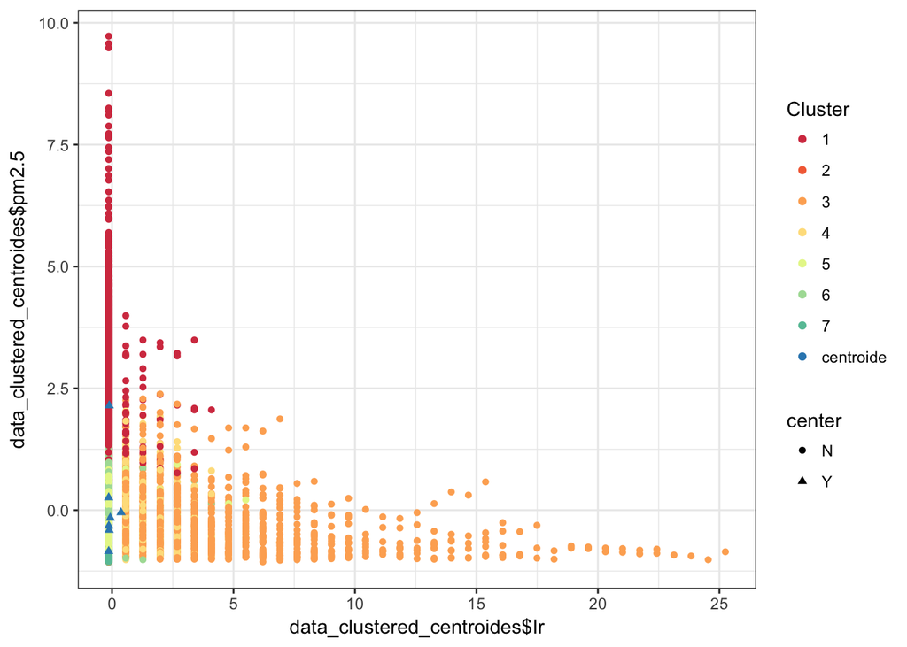

```r
ggplot(data_clustered_centroides, aes(x=data_clustered_centroides$Ir, y=data_clustered_centroides$pm2.5,
                                    color= as.factor(cluster), shape=center)) + geom_point() + scale_color_brewer(palette="Spectral",name="Cluster")+ theme_bw()
```